# Spatial AutoCorrelation

Manufacturing Jobs in NC 1990-2000

Dan Miller

2023-11-04

# Packages Used

```r
library(sf)
library(spdep)
library(tmap)
```

# Loading Data and Setting CRS

```r
NC <- read_sf("NC_REGION/NC_REGION.shp")

#st_crs("EPSG:26917")

#class(st_crs("EPSG:26917"))

# The 'crs' argument works best when we give it an object of class 'crs', such
# as what's given by the st_crs() function

NC_UTM <- st_transform(NC, crs = st_crs("EPSG:26917"))
```

# Queens Case:

**Creating Nearest Neighbor Spatial Objects**

```r
queen_nb <- poly2nb(NC_UTM, queen = TRUE)
NC_centroids <- st_centroid(NC_UTM)
## Warning in st_centroid.sf(NC_UTM): st_centroid assumes attributes are constant over
## geometries of x

nc_coords <- NC_centroids$geometry

nb_lines <- nb2lines(nb = queen_nb,
                     coords = nc_coords)


queens_case_plot <-

  #plotting the borders of our nc counties
  tm_shape(NC_UTM) +
  tm_borders() +

#adding nb lines
tm_shape(nb_lines) +
  tm_lines() +
#adding centroid dot for NC counties
tm_shape(NC_centroids) +
  tm_dots(size = 0.125)
```

### Plot 1: Queens Case

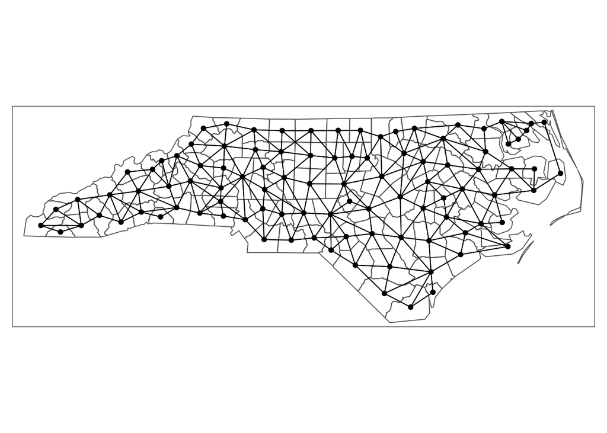

```r
queens_case_plot
```

**Creating wij Weight Matrix Using the above Queen’s Case Spacial Object**

```r
queen_nb_w <- nb2listw(
neighbours = queen_nb,
  # The default style, "W", tells us that we're performing row standardization
style = "W",
# Don't worry about this option for now, but it'll be important to include # later.
zero.policy = TRUE,
)
#Summary Statistics of Our Weights matrix
summary(queen_nb_w)
```

```
Characteristics of weights list object:
Neighbour list object:
Number of regions: 100
Number of nonzero links: 490
Percentage nonzero weights: 4.9
Average number of links: 4.9
Link number distribution:

 2  3  4  5  6  7  8  9
 8 15 17 23 19 14  2  2
8 least connected regions:
4 21 45 56 77 80 90 99 with 2 links
2 most connected regions:
39 67 with 9 links

Weights style: W
Weights constants summary:
    n    nn  S0       S1       S2
W 100 10000 100 44.65023 410.4746
```

## Testing for Spatial Autocorrelation using Morans’s I

**Manufacturing Jobs in 2000**

```r
queen <- moran.test(
  x = NC_UTM$MNEM2000,
  listw = queen_nb_w,
  zero.policy = TRUE,
  alternative = "two.sided"
)
queen$estimate[1]
```

```
Moran I statistic
        0.3884704
```

Calculating Moran’s I & p-values for Different Variables **1. Calculate Moran’s I for the following variables in the dataset. List the Moran’s I values and p-values for each variable in a single summary table: • MNEM2000 • MNEM1990 • TOTJOB2000 • TOTJOB1990**

Long Format:

```r
dans_moran_queen <- function(x, variable) {
 value <- moran.test(
  x = x,
  listw = queen_nb_w,
  zero.policy = TRUE,
  alternative = "two.sided"
)
 p.value <- value$p.value
 Morans_I_Stat <- value$estimate[1]
 title <- paste(variable)
 combined <- list(title,value, p.value, Morans_I_Stat)
  return(combined)
}


test_variables <- list(NC_UTM$MNEM2000, NC_UTM$MNEM1990, NC_UTM$TOTJOB2000, NC_UTM$TOTJOB1990)
names_v <-  list( "MNEM2000", "MNEM1990", "TOTJOB2000", "TOTJOB1990")
stuff <-mapply(dans_moran_queen, x = test_variables, variable = names_v, SIMPLIFY = FALSE)



p_values <- sapply(stuff, function(result) result[[3]])
Morans_I <- sapply(stuff, function(result) result[[4]])

# Create a data frame
result_df <- data.frame(variable = c("MNEM2000", "MNEM1990", "TOTJOB2000", "TOTJOB1990"), p.value = p_values, Morans_I = Morans_I)

summary_table <- data.frame(t(result_df))
result_df
```

```
    variable      p.value  Morans_I
1   MNEM2000 3.238771e-10 0.3884704
2   MNEM1990 7.468829e-12 0.4283699
3 TOTJOB2000 3.587933e-03 0.1631958
4 TOTJOB1990 4.264945e-03 0.1642235
```

Wide:

```r
summary_table
```

```
                   X1           X2           X3           X4
variable     MNEM2000     MNEM1990   TOTJOB2000   TOTJOB1990
p.value  3.238771e-10 7.468829e-12 3.587933e-03 4.264945e-03
Morans_I    0.3884704    0.4283699    0.1631958    0.1642235
```

# Rooks, knn, and distance based Neighest Neighbor

**Calculate Moran’s I for the MNEM2000 variable using four different versions of 𝑊𝑖𝑗:** • Queen’s Case • Rook’s Case • 𝑘 = 4 nearest neighbors • Maximum Distance (100% threshold)

**Bringing in code from previous module:** so that we have the `NC_knn1` object which I’ve tweaked to call `NC_knn4`, and the `NC_dnn` object.

### Rooks

Spatial Weights Matrix & Testing Morans I

```r
rook_nb_w <- NC_UTM %>%
tibble::column_to_rownames("NAME") %>%
  st_as_sf() %>%
  poly2nb(queen = F) %>%
  nb2listw(
style = "W",
    zero.policy = TRUE
  )


morans_rook <- moran.test(
  x = NC_UTM$MNEM2000,
  listw = rook_nb_w,
  zero.policy = T,
  alternative = "two.sided"
)


morans_rook
```

```
    Moran I test under randomisation

data:  NC_UTM$MNEM2000
weights: rook_nb_w

Moran I statistic standard deviate = 6.3762, p-value = 1.815e-10
alternative hypothesis: two.sided
sample estimates:
Moran I statistic       Expectation          Variance
      0.404484123      -0.010101010       0.004227639
```

plot:

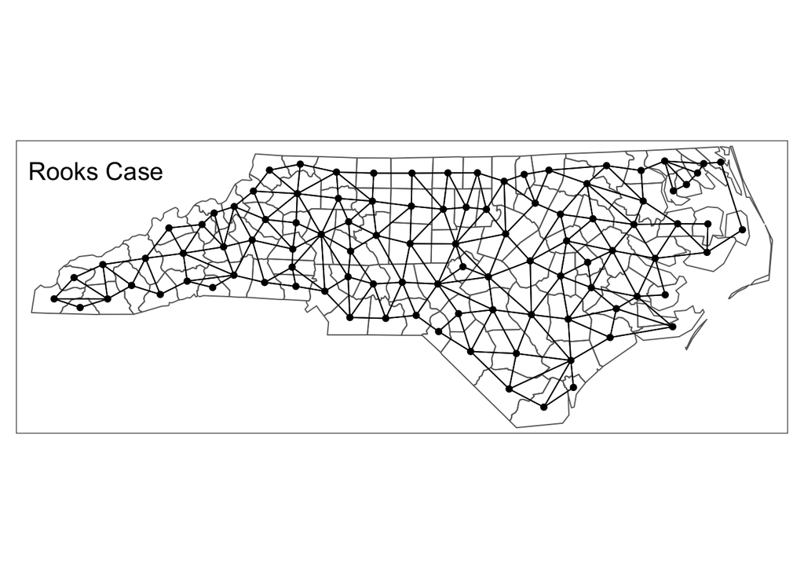

```r
### rooks case
rook_nb <- poly2nb(NC_UTM, queen = FALSE)
NC_centroids <- st_centroid(NC_UTM)
## Warning in st_centroid.sf(NC_UTM): st_centroid assumes attributes are constant over
## geometries of x

nc_coords <- NC_centroids$geometry

nb_lines_r <- nb2lines(nb = rook_nb,
                     coords = nc_coords)

rooks_case_plot <-

  #plotting the borders of our nc counties
  tm_shape(NC_UTM) +
  tm_borders() +
 tm_layout(title= 'Rooks Case', title.position = c('left', 'top')) +
#adding nb lines
tm_shape(nb_lines_r) +
  tm_lines() +
#adding centroid dot for NC counties
tm_shape(NC_centroids) +
  tm_dots(size = 0.125)

rooks_case_plot
```

### Knn

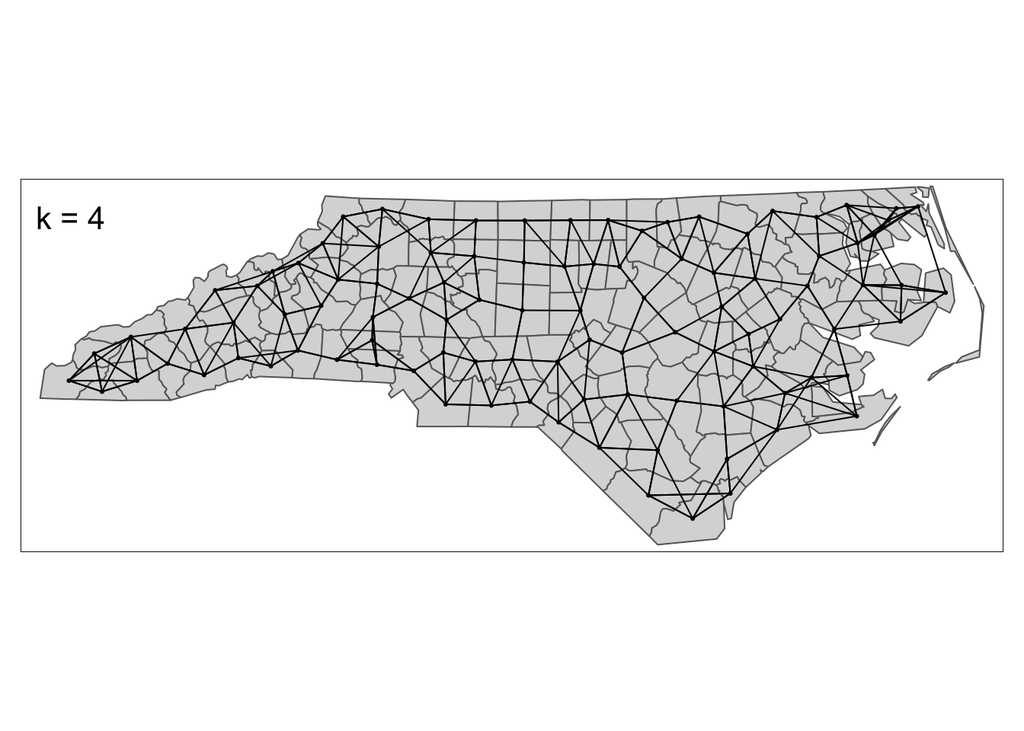

```r
############# knn, k = 4
# We'll use the county name as the row names. Unlike in poly2nb, the row.names
# argument actually seems to work :)
NC_knn4 <- knn2nb(
  knn = knearneigh(x = NC_centroids,
                   k = 4),
  row.names = NC_UTM$NAME
)
# Now, let's make a plot. Remember, the nb2lines function is used to convert a


# neighbor list object into an "sf-compatible" object which we can map.
knn_lines <- nb2lines(
  nb = NC_knn4,
  coords = nc_coords
)
map_knn4 <- qtm(NC_UTM, title = "k = 4") +
  qtm(knn_lines) +
  qtm(NC_centroids)

map_knn4
```

### Distance

```r
################ distances for K = 4
dist <- nbdists(nb = NC_knn4,
                coords = nc_coords) %>%
  # We'll use the unlist() function to convert our list of distances to a vector, which is easier to compare.
unlist()
summary(dist)
```

```
   Min. 1st Qu.  Median    Mean 3rd Qu.    Max.
  12245   31718   37032   37742   42654   77248
```

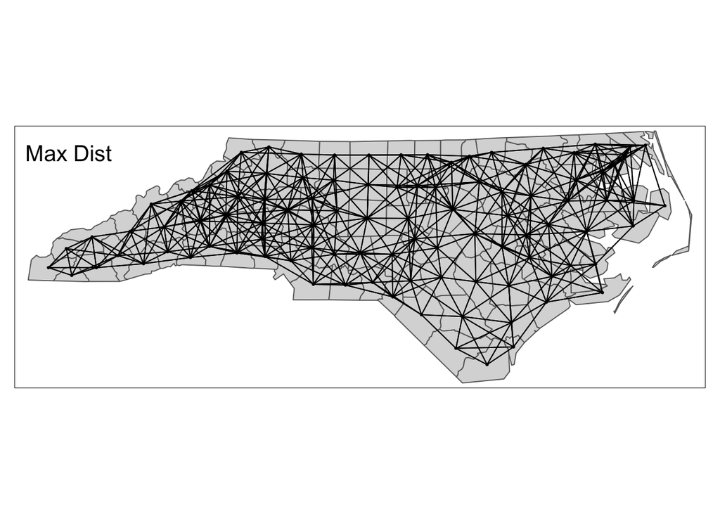

```r
############### max distance of K = 4
max_dist <- max(dist)

############## nn based on the above distance
NC_dnn <- dnearneigh(x = NC_centroids,
  d1 = 0,
  d2 = max_dist,
  row.names = NC_UTM$NAME
)
NC_dnn_sf <- nb2lines(
  NC_dnn, coords = nc_coords
)
map_maxd <- qtm(NC_UTM, title = "Max Dist") +
  qtm(NC_dnn_sf) +
  qtm(NC_centroids)


map_maxd
```